# DARE-2

Seulbi Lee, Havi Khurana, Janette Avelar

2024-02-04

```r
# Make bins
# For each bin created, it uses the gsub function to extract the lower bound of the bin. The regular expression pattern (.*)(,)(.*) is used to find and capture the characters before the comma, which represents the lower bound of the interval, and replaces the whole string with just this captured group (indicated by \\1).

# api_val_5 is recalculated by parsing the lower bound of each bin to a numeric value using parse_number and then adding 2.5. This calculates the midpoint of each 5-unit interval.

dat <- dat |>
    mutate(api_bin_5 = cut(norm,
                         breaks = seq(-100, 100, 5)),
           api_val_5 = gsub("(.*)(,)(.*)","\\1", api_bin_5),
           api_val_5 = readr::parse_number(api_val_5) + 2.5,
           api_bin_3 = cut(norm,
                           breaks = seq(-99, 99, 3)),
           api_val_3 = gsub("(.*)(,)(.*)","\\1", api_bin_3),
           api_val_3 = readr::parse_number(api_val_3) + 1.5)
```

### A. Assumption tests

**A1.** Figure 1 shows receiving Williams Settlement textbook funding in 2005 as a function of Academic Performance Index (API) rank in 2003, centered at the threshold of 643. In the graph, the vertical dotted line represents the cutoff score for eligibility, as determined at each school level. All elementary schools, except one, with an API rank of less than or equal to 643 received textbook funds whereas no school with an API rank of more than 643 received funds. As expected, there is a sharp change at the cutoff, with schools below the API cutoff receiving textbook funding in 2005. Thus, API score is a forcing variable for receiving textbook funding with one sharp point of discontinuity.

```r
# Figure without binning
# dat %>%
#   ggplot() +
#   geom_jitter(aes(api_rank, receive_williams),
#               color = "gray", alpha = 0.4, shape = 16) +
#   geom_line(aes(api_rank, ind),
#             color = "red", linetype = "dashed", size = 1.5) +
#   theme_pander(base_size = 15) +
#   labs(x = "API rank in 2003",
#        y = "Williams recipient in 2005",
#        title = "Receiving Funds vs API score",
#        subtitle = "Without binning")
```

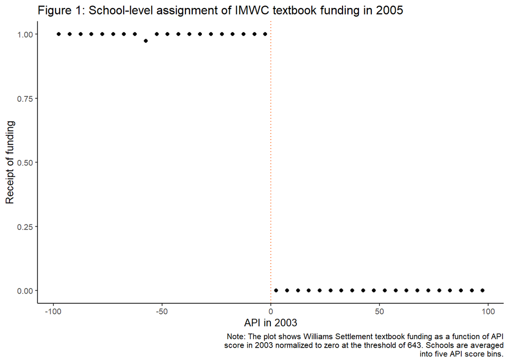

```r
#Figure 1 - forcing variable and treatment

fig_a1 <- dat %>%
    filter(year == "2005") %>%
    group_by(api_bin_5) %>%
    mutate(receive_williams = mean(receive_williams, na.rm = T)) %>%
    dplyr::select(api_bin_5, api_val_5, receive_williams) %>%
    unique() %>%
    filter(!is.na(api_bin_5)) %>%
    ggplot() +
    geom_point(aes(x = api_val_5, y = receive_williams)) +
    geom_vline(xintercept = 0, linetype = "dotted", color = red) +
    labs(x = "API in 2003",
         y = "Receipt of funding",
         title = "Figure 1: School-level assignment of IMWC textbook funding in 2005",
         caption = stringr::str_wrap("Note: The plot shows Williams Settlement textbook funding as a function of API score in 2003 normalized to zero at the threshold of 643.\nSchools are averaged into five API score bins.")
         )+
    theme_classic(10)

fig_a1
```

**A2.** One of the identifying assumptions of a regression discontinuity design is that there is no non-random sorting into treatment groups and that the counterfactual is equal in expectation to the treatment group around the discontinuity. To examine whether schools manipulated their 2003 API score in order to get eligible for Williams fund, we inspected a few different trends in the data.

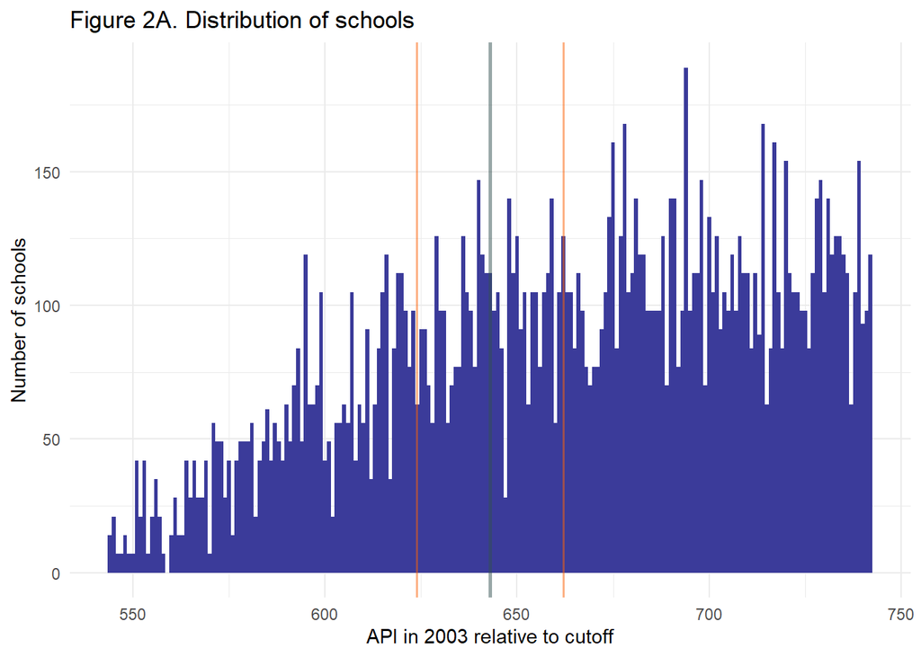

```r
fig_a2_1a <- ggplot(data = dat, aes(x = api_rank)) +
  geom_histogram(fill = blue, binwidth = 1) +
  geom_vline(
    xintercept = 643,
    color = slate,
    size = 1,
    alpha = 0.5
  ) +
  geom_vline(
    xintercept = 643 + 19.099,
    color = red,
    size = 0.7,
    alpha = 0.5
  ) +
  geom_vline(
    xintercept = 643 - 19.099,
    color = red,
    size = 0.7,
    alpha = 0.5
  ) +
  theme_minimal(base_size = 18) +
  labs(x = "API in 2003 relative to cutoff",
       y = "Number of schools",
       title = "Figure 2A. Distribution of schools") +
  theme_minimal()

fig_a2_1a
```

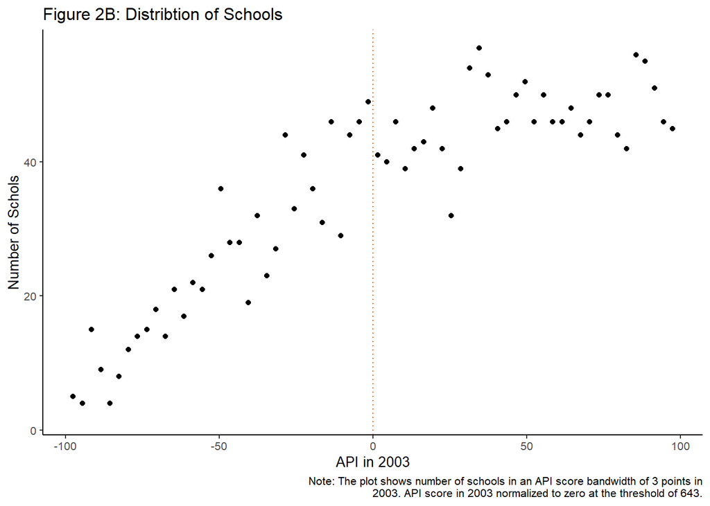

```r
fig_a2_1b <- dat %>%
    filter(year == "2003") %>%
    group_by(api_bin_3, api_val_3) %>%
    summarise(n_school = n()) %>%
    ggplot()+
    geom_point(aes(x = api_val_3, y = n_school))+
    geom_vline(xintercept = 0, linetype = "dotted", color = red) +
    labs(x = "API in 2003",
         y = "Number of Schols",
         title = "Figure 2B: Distribtion of Schools",
         caption = stringr::str_wrap("Note: The plot shows number of schools in an API score bandwidth of 3 points in 2003. API score in 2003 normalized to zero at the threshold of 643.")
         )+
    theme_classic(10)

fig_a2_1b
```

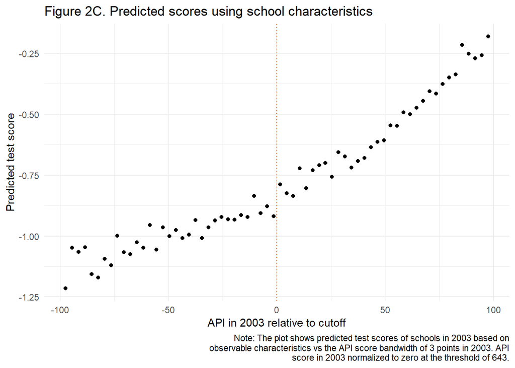

```r
dat_a2_1c <- dat  |>
  filter(year == "2003")

pt_score_model <-
  feols(
    average_score ~ pct_ai + pct_as + pct_pi + pct_fi + pct_hi + pct_aa + pct_wh + pct_other + percentfrl + classsize + yrs_teach + yrs_dist + total,
    data = dat_a2_1c
  )

# saving the predict in a new column
dat_a2_1c$predict <- predict(pt_score_model)

# plot predicted vs api_bin
fig_a2_1c <- dat_a2_1c  |>
  group_by(api_bin_3, api_val_3)  |>
  mutate(predict = mean(predict, na.rm = T))  |>
  dplyr::select(api_bin_3, api_val_3, predict)  |>
  unique()  |>
  filter(!is.na(api_bin_3))  |>
  ggplot() +
  geom_point(aes(x = api_val_3, y = predict)) +
  geom_vline(xintercept = 0,
             linetype = "dotted",
             color = red) +
  labs(x = "API in 2003 relative to cutoff",
       y = "Predicted test score",
       title = "Figure 2C. Predicted scores using school characteristics",
       caption = stringr::str_wrap("Note: The plot shows predicted test scores of schools in 2003 based on observable characteristics vs the API score bandwidth of 3 points in 2003. API score in 2003 normalized to zero at the threshold of 643.")) +
  theme_minimal()

fig_a2_1c
```

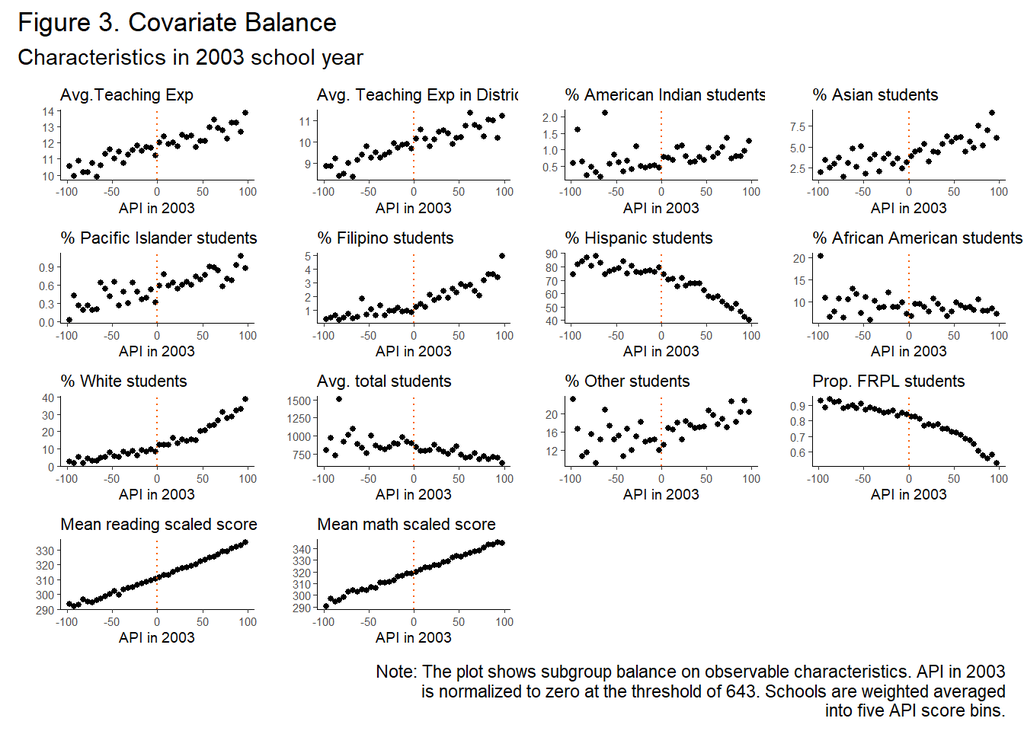

```r
# observables just above and below the threshold

fig_a2_data <- dat %>%
    filter(year == "2003") %>%
    group_by(api_bin_5) %>%
    mutate(
        across(
            c(yrs_teach:percentfrl, readingscore, mathscore),
            ~Hmisc::wtd.mean(.x, weights = total, na.rm = T))) %>%
    select(api_val_5, yrs_teach:percentfrl, readingscore, mathscore) %>%
    unique() %>%
    filter(!is.na(api_bin_5))

plot_title_names <- c(
    "Avg.Teaching Exp",
    "Avg. Teaching Exp in District",
    "% American Indian students",
    "% Asian students",
    "% Pacific Islander students",
    "% Filipino students",
    "% Hispanic students",
    "% African American students",
    "% White students",
    "Avg. total students",
    "% Other students",
    "Prop. FRPL students",
    "Mean reading scaled score",
    "Mean math scaled score")

fig_a2_2 <- purrr::map2(colnames(fig_a2_data)[3:16], plot_title_names,
                 ~ggplot(fig_a2_data) +
                     geom_point(aes_string(x = "api_val_5", y = .x), size = 1) +
                     geom_vline(xintercept = 0, linetype = "dotted", color = red) +
                     labs(x = "API in 2003",
                          y = "",
                          title = .y
                     )+
                     theme_classic(7))
#fig_a2_2

wrap_plots(fig_a2_2,
           nrow =  4, ncol = 4) +
    plot_annotation(title = "Figure 3. Covariate Balance",
                    subtitle = "Characteristics in 2003 school year",
                    caption = stringr::str_wrap("Note: The plot shows subgroup balance on observable characteristics. API in 2003 is normalized to zero at the threshold of 643. Schools are weighted averaged into five API score bins."))
```

### B. Replication and Extension

[figure not shown]

```r
fig_b1 <- dat %>%
  filter(year == "2005") %>%
  group_by(api_bin_5) %>%
  mutate(average_score = Hmisc::wtd.mean(average_score, weights = total, na.rm = T)) %>%
  dplyr::select(api_bin_5, api_val_5, average_score) %>%
  unique() %>%
  filter(!is.na(api_bin_5)) %>%
  ggplot() +
  geom_point(aes(x = api_val_5, y = average_score)) +
  geom_vline(
    xintercept = 0,
    linetype = "dotted",
    color = slate,
    alpha = 1
  ) +
  geom_vline(
    xintercept = -19.099,
    linetype = "solid",
    color = red,
    alpha = 0.7
  ) +
  geom_vline(
    xintercept = 19.099,
    linetype = "solid",
    color = red,
    alpha = 0.7
  ) +
  labs(x = "API in 2003 relative to cutoff",
       y = "Average scaled score",
       title = "Figure 4A: Effect of funding on 2005 average scores",
       caption = stringr::str_wrap("Note: The plot shows predicted test scores of schools in 2003 based on observable characteristics vs the API score bandwidth of 3 points in 2003. API score in 2003 normalized to zero at the threshold of 643.")) +
  theme_minimal()

fig_b1
```

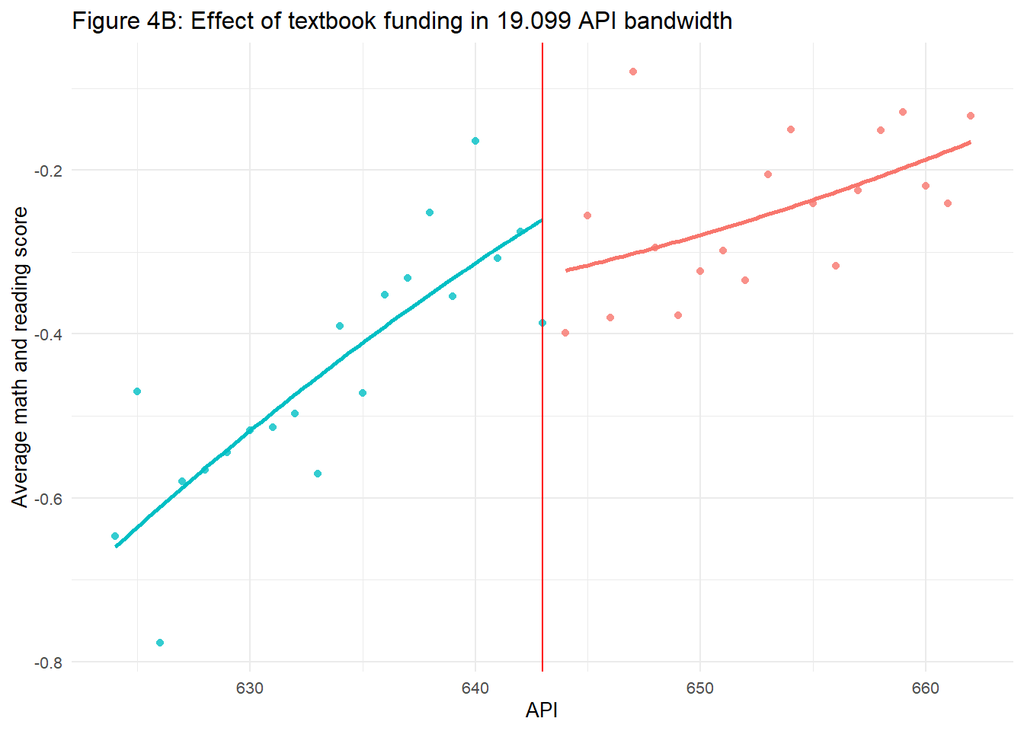

```r
dat %>%
  filter(api_rank >= 623.901 & api_rank <= 662.099) %>%
  mutate(ind = factor(ind)) %>%
  group_by(api_rank) %>%
  summarise(across(c("average_score", "ind"), mean)) %>%
  mutate(condition = ifelse(api_rank <= 643, "Received funding", "Did not receive funding")) %>%
  ggplot(aes(api_rank, average_score, color = condition)) +
  geom_point(alpha = 0.8, shape = 16) +
  geom_smooth(method = "lm",
              formula = y ~ poly(x, 2),
              se = FALSE) +
  geom_vline(xintercept = 643,
             color = "red",
             linewidth = .5) +
  theme_minimal(base_size = 10) +
  theme(legend.position="none") +
  labs(x = "API",
       y = "Average math and reading score",
       color = "Condition",
       title = "Figure 4B: Effect of textbook funding in 19.099 API bandwidth")
```

**B2.**

**Table 1**

```r
#2005 Model
dat05 <- dat %>%
    filter(year == "2005") %>%
    filter(norm > -19.099 & norm < 19.099) %>%
    mutate(treatment = ifelse(norm > 0, 0, 1),
           treatment = factor(treatment, levels = c(0,1)))

mod05 <- feols(average_score ~ treatment*norm + yrs_teach + yrs_dist + pct_ai + pct_as + pct_pi + pct_fi + pct_hi + pct_aa + pct_wh + total + percentfrl,
               data = dat05,
               vcov = ~distid)

#2006 Model
dat06 <- dat %>%
    filter(year == "2006") %>%
    filter(norm > -19.099 & norm < 19.099) %>%
    mutate(treatment = ifelse(norm > 0, 0, 1),
           treatment = factor(treatment, levels = c(0,1)))
mod06 <- feols(average_score ~ treatment*norm + yrs_teach + yrs_dist + pct_ai + pct_as + pct_pi + pct_fi + pct_hi + pct_aa + pct_wh + total + percentfrl,
                 data = dat06,
               vcov = ~distid)
#2007 Model
dat07 <- dat %>%
    filter(year == "2007") %>%
    filter(norm > -19.099 & norm < 19.099) %>%
    mutate(treatment = ifelse(norm > 0, 0, 1),
           treatment = factor(treatment, levels = c(0,1)))
mod07 <- feols(average_score ~ treatment*norm + yrs_teach + yrs_dist + pct_ai + pct_as + pct_pi + pct_fi + pct_hi + pct_aa + pct_wh + total + percentfrl,
                 data = dat07,
               vcov = ~distid)
#2008 Model
dat08 <- dat %>%
    filter(year == "2008") %>%
    filter(norm > -19.099 & norm < 19.099) %>%
    mutate(treatment = ifelse(norm > 0, 0, 1),
           treatment = factor(treatment, levels = c(0,1)))
mod08 <- feols(average_score ~ treatment*norm + yrs_teach + yrs_dist + pct_ai + pct_as + pct_pi + pct_fi + pct_hi + pct_aa + pct_wh + total + percentfrl,
                 data = dat08,
               vcov = ~distid)
#2009 Model
dat09 <- dat %>%
    filter(year == "2009") %>%
    filter(norm > -19.099 & norm < 19.099) %>%
    mutate(treatment = ifelse(norm > 0, 0, 1),
           treatment = factor(treatment, levels = c(0,1)))
mod09 <- feols(average_score ~ treatment*norm + yrs_teach + yrs_dist + pct_ai + pct_as + pct_pi + pct_fi + pct_hi + pct_aa + pct_wh + total + percentfrl,
                 data = dat09,
               vcov = ~distid)

#table
modelsummary(list("2005" = mod05,
                  "2006" = mod06,
                  "2007" = mod07,
                  "2008" = mod08,
                  "2009" = mod09),
             estimate = "{estimate} [{conf.low},{conf.high}]",
             stars = TRUE,
             coef_map = c("treatment1" = "Received Funding"),
             gof_omit = "AIC|BIC|Log|RMSE|R2 .*",
             title = "Table 1. Effect of Textbook funding on Average Scores",
             notes = "Model estimates and 95% Confidence Intervals are presented. A bandwidth of 19.099 was selected around the threshold. Controls included demographic characteristics of students and teacher experience.")
```

Table 1. Effect of Textbook funding on Average Scores

|  | 2005 | 2006 | 2007 | 2008 | 2009 |
| --- | --- | --- | --- | --- | --- |
| Received Funding | 0.207 [0.045,0.369] | 0.180 [−0.054,0.415] | 0.190 [−0.046,0.426] | 0.134 [−0.079,0.347] | 0.167 [−0.033,0.367] |
|  | (0.082) | (0.119) | (0.120) | (0.108) | (0.101) |
| Num.Obs. | 536 | 536 | 536 | 536 | 536 |
| R2 | 0.161 | 0.141 | 0.144 | 0.140 | 0.116 |
| Std.Errors | by: distid | by: distid | by: distid | by: distid | by: distid |

+ p < 0.1, * p < 0.05, ** p < 0.01, *** p < 0.001  
Model estimates and 95% Confidence Intervals are presented. A bandwidth of 19.099 was selected around the threshold. Controls included demographic characteristics of students and teacher experience.

We estimated the following model using regression discontinuity design.

$$TestScore_{ist} = \alpha +
\delta*ReceivedWilliamsFund + \beta*APIScore_{2003} +
\gamma*APIScore_{2003}*ReceivedWilliamsFund + X_{ist} +
\epsilon_{it}$$

Using the model, our average estimated effect is 0.20 school-level SD units in 2005, just after the distribution of funds. At the 5% alpha-threshold level, we reject the null hypothesis that there is no causal effect of textbook funding on average scores in elementary schools in California. The 95% confidence interval is 0.04 SD units to 0.37 SD. Thus, our estimates indicates that the receipt of additional funds for textbooks improved test score outcomes for elementary students in California. This is consistent with Holden’s estimate reported in Table 5. We see non-significant estimates for other years.

**B3.**

In this analysis, we used a regression discontinuity design using the exogeneous textbook funding created by Williams settlement case in California. We found that textbook funding has a substantively positive effect on the test scores of California elementary school students. A one-time fund of $96 per student in textbook funding increased average improvement by 0.20 standard deviation units in school-level test scores, a statistically significant effect with a 95% confidence interval ranging from 0.04 to 0.37 standard deviation units. This effect size is not only statistically significant but potentially educationally meaningful, suggesting that the provision of additional textbook funding can contribute to improved academic outcomes.

The assumption checks conducted through the analysis provide confidence in these results. The lack of bunching around the cutoff and the continuity in school characteristics on either side of the threshold lend credence to the causal interpretation of the findings. These assumption tests are crucial as they underpin the validity of the regression discontinuity design, suggesting that the treatment — receipt of textbook funding — is as good as randomly assigned near the cutoff.

However, this study is not without limitations. The analysis is based on observed data, and although the regression discontinuity design helps to control for unobserved confounders near the cutoff, it cannot completely rule out all forms of bias. The causal estimate is local to the vicinity of the cutoff and may not generalize to schools with API scores far from the threshold or schools in other states. Additionally, this study captures the short-term impact of textbook funding, and it would be important to investigate the long-term effects to fully understand the implications of such policy interventions. The sample also excludes certain big special populations, such as students with disabilities, by using the CSAT measure.